# Statystyki walidacji klastrów

Michał Stawikowski

25 - 05 - 2019

# 1 Wprowadzenie

Celem raportu jest przedstawienie różnych statystyk walidacji klastrów. Grupowanie obserwacji przeprowadzać będę na zbiorze `Heart Disease UCI`, który zawiera dane na temat chorób serca u pacjentów. Docelowo zbiór będziemy chcieli podzielić na pacjentów chorych i zdrowych, lub ze względu na rodzaj choroby. Do klastrowania wykorzystamy cztery algorytmy:

- `Kmeans`
- dwa algorytmy z grupy `Agglomeration methods`:
  - `Centroid`
  - `Ward`
- oraz algorytm z grupy `EM`:
  - `Gaussian Mixture Models`

# 2 Statystyki walidacji - internal criteria

Do wybierania odpowiedniej liczby klastrów dla zbioru i metody grupowania, będziemy używać wybranych statystyk podanych w [artykule](https://www.researchgate.net/publication/2500099_On_Clustering_Validation_Techniques):

- `Hubert` (modified) statistic
- `The Davies-Bouldin (DB) index`
- `Dunn index`

oraz innych omówionych na wykładzie, takich jak:

- `Elbow method`
- `Silhouette method`
- `Gap statistic method`

Korzystał będę z implementacji z pakietu `NBClust`.

## 2.1 Kmeans

### 2.1.1 Pojedyncze metody

#### 2.1.1.1 Hubert

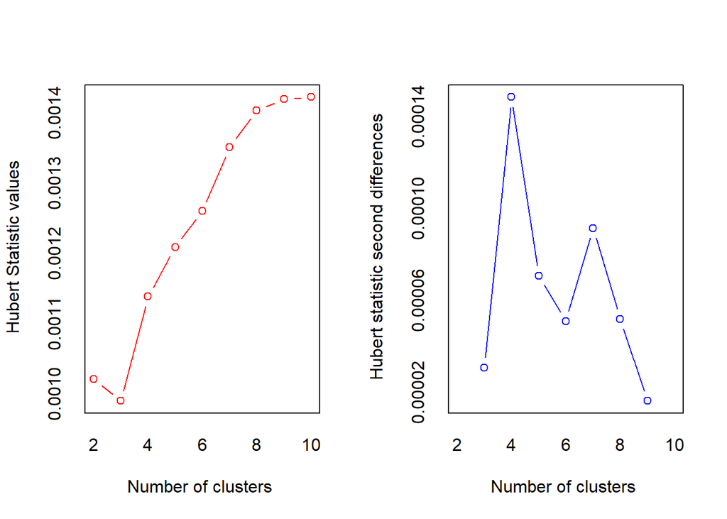

```
FALSE *** : The Hubert index is a graphical method of determining the number of clusters.
FALSE                 In the plot of Hubert index, we seek a significant knee that corresponds to a
FALSE                 significant increase of the value of the measure i.e the significant peak in Hubert
FALSE                 index second differences plot.
FALSE
```

`Hubert` index jest metodą graficzną i najlepszą liczbę klastrów wybieramy na podstawie `kolana` występującego na drugim wykresie, który prezentuje albo gwałtowny wzrost wartości albo gwałtowny spadek. W tym wypadku widzimy praktycznie pionową linię w punkcie 4 - to optymalna liczba klastrów wybrana przez ten algorytm.

#### 2.1.1.2 The Davies-Bouldin index

```r
set.seed(1)
res.nbclust <- Data %>%
  NbClust(distance = "euclidean",
          min.nc = 2, max.nc = 10,
          method = "kmeans", index ="db")
res.nbclust$Best.nc
```

```
## Number_clusters     Value_Index
##         10.0000          2.0045
```

Index `DB` jako optymalną wartość wybrał 10 klastrów.

#### 2.1.1.3 Statystka Dunna

```r
res.nbclust <- Data %>%
  NbClust(distance = "euclidean",
          min.nc = 2, max.nc = 10,
          method = "kmeans", index ="dunn")
res.nbclust$Best.nc
```

```
## Number_clusters     Value_Index
##          4.0000          0.1768
```

Na 4 klastry zdecydował się algorytm `Dunna`.

#### 2.1.1.4 Elbow method

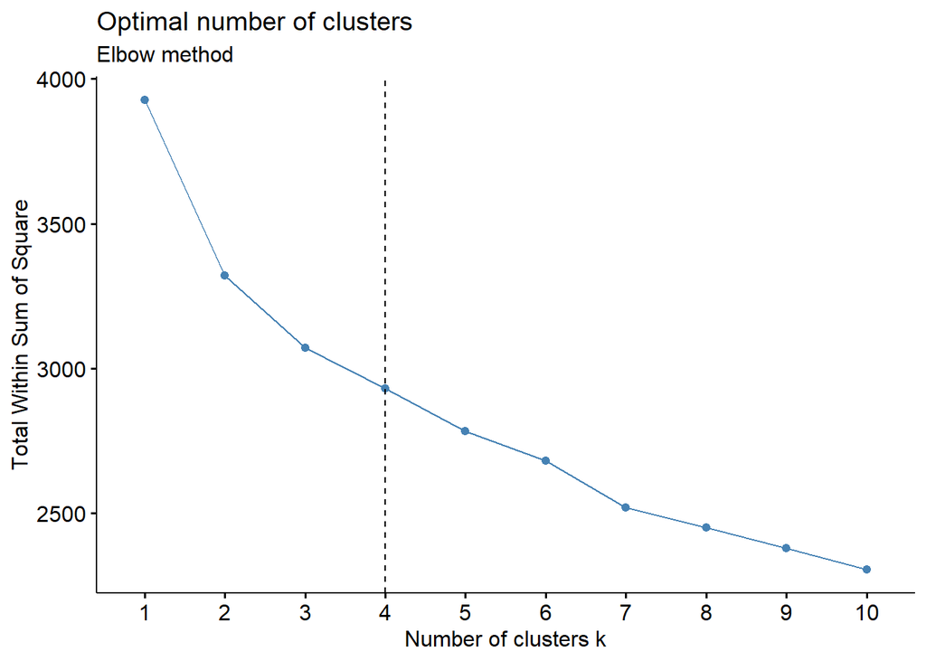

```r
# Elbow method
fviz_nbclust(Data, kmeans, method = "wss") +
    geom_vline(xintercept = 4, linetype = 2)+
  labs(subtitle = "Elbow method")
```

Metoda `Elbow` - 4 klastry.

#### 2.1.1.5 Silhouette method

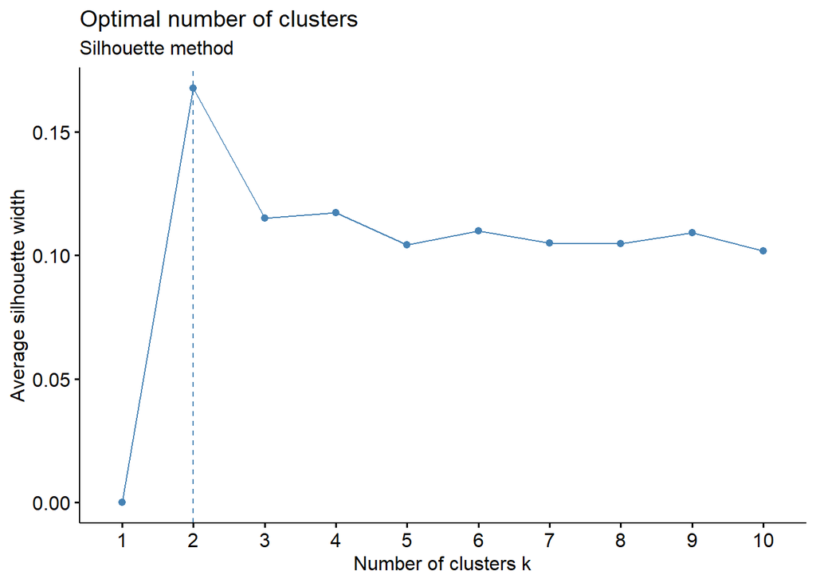

```r
# Silhouette method
fviz_nbclust(Data, kmeans, method = "silhouette")+
  labs(subtitle = "Silhouette method")
```

```
##   cluster size ave.sil.width
## 1       1  203          0.15
## 2       2  100          0.10
```

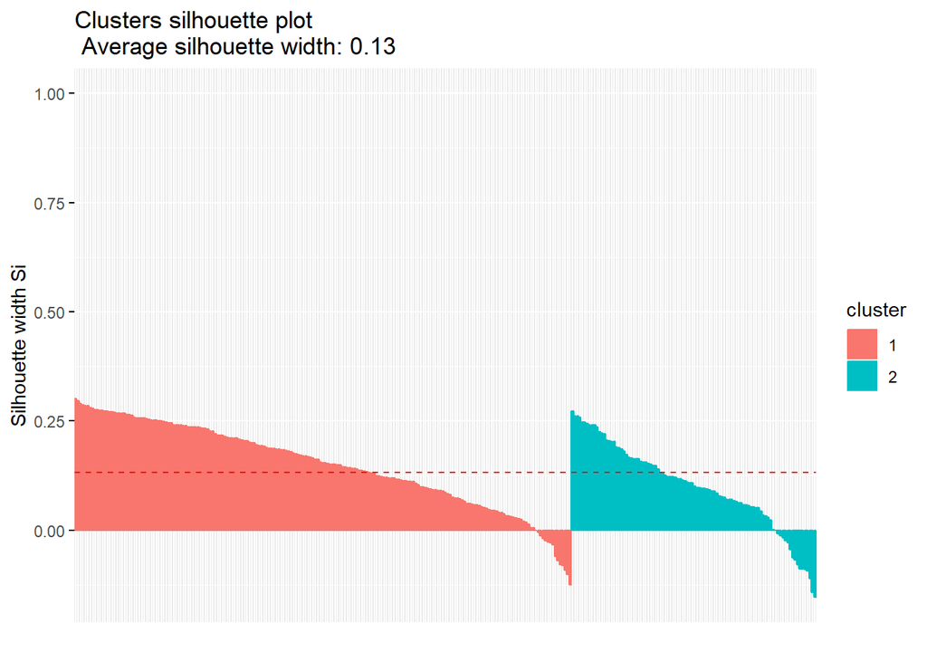

```r
res.hc4 <- Data %>%
  eclust("hclust", k = 2, graph = FALSE)
fviz_silhouette(res.hc4)
```

```
##   cluster size ave.sil.width
## 1       1   34          0.09
## 2       2   92          0.18
## 3       3   77          0.10
## 4       4  100          0.04
```

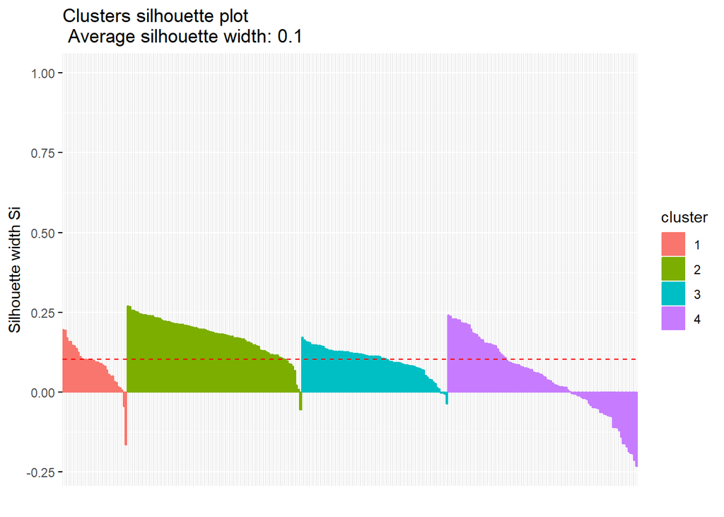

```r
res.hc4 <- Data %>%
  eclust("hclust", k = 4, graph = FALSE)
fviz_silhouette(res.hc4)
```

`Silhouette method` - Metody bada, czy obserwacje w klastrach są podobne do siebie, na podstawie odległości lub innych metryk i na podstawie tego każdej obserwacji przydziela wartość `Sillhouette width` - od -1 do 1. Czym większa wartość tym obserwacja lepiej pasuje do swojego klastra. Na podstawie całego zbioru liczy się średnie `Sillhouette width` i na podstawie tego wybiera optymalną liczbę klastrów. Na powyższym wykresie możemy zobaczyć jak prezentują się te wartości dla liczby klastróW: 2 oraz 4. Jak widać 2 osiągnęła lepszy wynik.

#### 2.1.1.6 Gap statistic

```
## Clustering k = 1,2,..., K.max (= 10): .. done
## Bootstrapping, b = 1,2,..., B (= 50)  [one "." per sample]:
## .................................................. 50
```

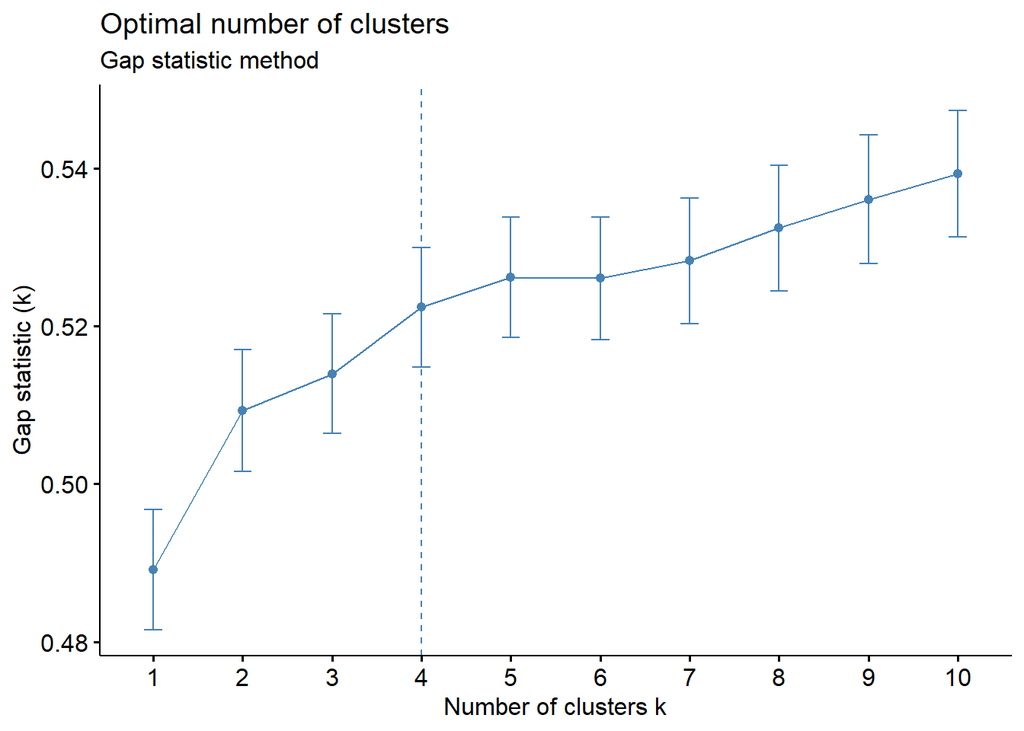

```r
# Gap statistic

set.seed(123)
fviz_nbclust(Data, kmeans, nstart = 25,  method = "gap_stat", nboot = 50)+
  labs(subtitle = "Gap statistic method")
```

`Gap statistic method` - 4 klastry

Jeden spośród sześciu algorytmów wybrało 2 jako optymalną liczbę klastrów, taka sama ilości algorytmów przystała na 10 grup, pozostałe zdecydowały się na 4 - mamy więc znaczną przewagę dla ostaniej wartosći, więc prawdopobnie powiniśmy podzielić zbiór na 4 klastry. Zobaczymy czy jeśli weźmiemy pod uwagę większą liczbę statystyk dojdziemy do takich samych wniosków.

### 2.1.2 Podsumowanie 30 różnych metod

Skorzystamy z pomocy indeksów z pakietu `NBClust`, które są zakodowane jako:`"kl", "ch", "hartigan", "ccc", "scott",` `"marriot", "trcovw", "tracew", "friedman", "rubin",` `"cindex", "db", "silhouette", "duda", "pseudot2", "beale",` `"ratkowsky", "ball", "ptbiserial", "gap", "frey", "mcclain" "dunn",` `"hubert", "sdindex", "dindex", "sdbw"`, aby sprawdzić czy uda nam się jednoznacznie wybrać liczbę klastrów.

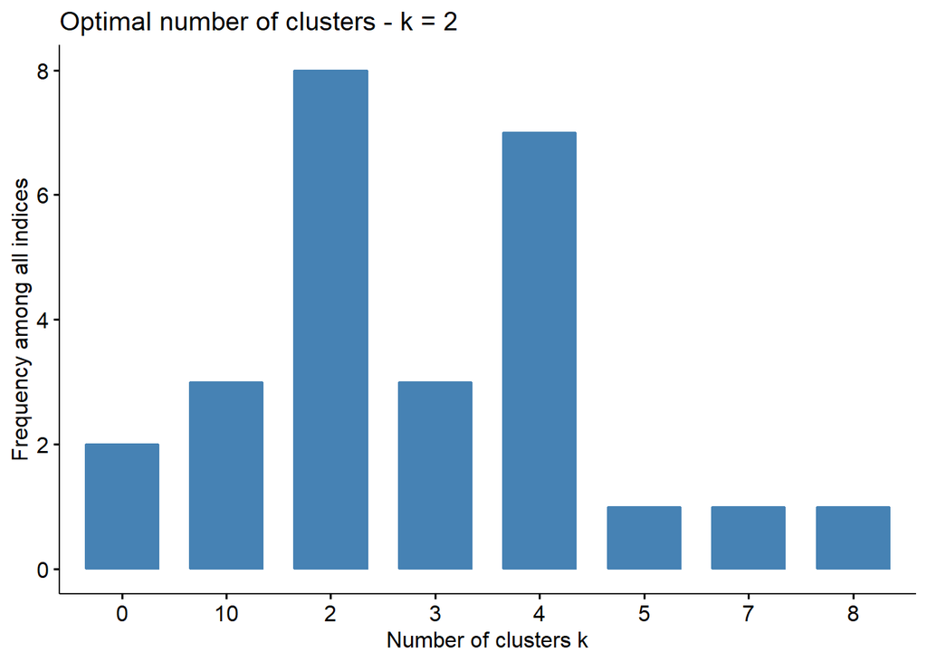

```r
p
```

Tym razem najwięcej statystyk wskazało 2 jako optymalną liczbę klastrów, chociaż 4 w cale nie jest daleko w tyle. Może wynikać to z charakterystyki zbioru, który można dzielić ze względu na osoby chorę i zdrowe, jak i ze względu na rodzaj choroby. Niektóre statystyki nie zwrócily w przypadku tej metody klastrowanie wyników, co może świadczyć o tym, że nie wszystkie współpracują ze wszystkimi algorytmami. Jak widać różne statystyki wcale nie dają zgodnych wyników.

# 3 Centroid

Tym razem przejdziemy od razu do podsumowania i sprawdzenia wyników dla 30 statystyk.

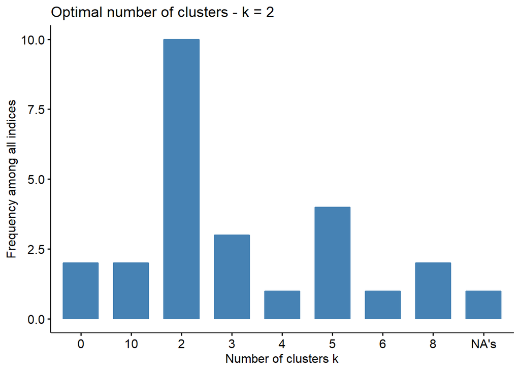

```r
p
```

Kolejny raz większość statystyk wskazało 2 jako optymalną liczbę grup, choć tym razem, drugą pod względem ilośći głosów jest grupa, która zagłosowała na 5. Pokazuje to, że także algorytm klastrowania ma wpływ na wybór liczby klastrów.

# 4 Ward

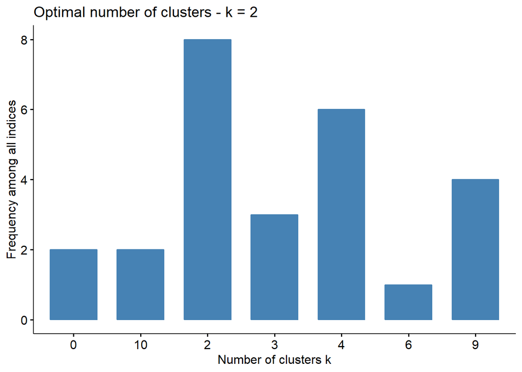

```r
p
```

W tym przypadku także 2 okazała sie najczęściej wybieraną wartością. Poza tym widzimy już wcześniej popularną 4 i nowy pik w 9. Na podstawie uzyskanych rezultatów można stwierdzić, że przy wyborze liczby klastróW najlepiej brać pod uwagę nie pojedyncze statystki lecz ich grupy, a także to, że różne algorytmy klasteryzacji nie zawsze są ze sobą w 100% zgodne.

# 5 External criteria

Innym sposobem walidacji klasteryzacji jest porównanie wyników z prawdziwymi etykietami, o ile takie posiadamy. Statyką, której do tego użyjemy będzie `Rand index`, a konkretniej `Adjusted Rand index` z pakietu `ClusterR`. Porównuje on etykiety zwrócone przez algorytm z tymi prawdziwymi, na podstawie czego porównuje oba podziały.

## 5.1 Gaussian Mixture Models

GMM to algorytm z rodzaju EM (Expectation – Maximalization), w któym zakłada się, że zbiór danych można opisać mieszaniną rozkładów normalnych. Algorytm GMM wymaga podania a priori liczby klastrów:

```r
#skalowanie i centrowanie
dat = center_scale(data, mean_center = T, sd_scale = T)

gmm = GMM(dat, 2, dist_mode = "maha_dist", seed_mode = "random_subset", km_iter = 10,

          em_iter = 10, verbose = F)

pr = predict_GMM(dat, gmm$centroids, gmm$covariance_matrices, gmm$weights)
```

Funkcja `Optimal_Clusters_GMM`, może być użyta do wyznaczenie optymalnej liczności klastróW. W tym przypadku do oceny wybraliśmy kryterium `Bayesian information`.

```r
opt_gmm = Optimal_Clusters_GMM(dat, max_clusters = 10, criterion = "BIC",

                               dist_mode = "maha_dist", seed_mode = "random_subset",

                               km_iter = 10, em_iter = 10, var_floor = 1e-10,

                               plot_data = T)
```

[output not shown]

```r
res = external_validation(targetdf$target, pr$cluster_labels,

                          method = "adjusted_rand_index", summary_stats = T)
```

```
##
## ----------------------------------------
## purity                         : 0.7195
## entropy                        : 0.7693
## normalized mutual information  : 0.1492
## variation of information       : 1.6214
## normalized var. of information : 0.9194
## ----------------------------------------
## specificity                    : 0.5366
## sensitivity                    : 0.6529
## precision                      : 0.5871
## recall                         : 0.6529
## F-measure                      : 0.6183
## ----------------------------------------
## accuracy OR rand-index         : 0.595
## adjusted-rand-index            : 0.1896
## jaccard-index                  : 0.4474
## fowlkes-mallows-index          : 0.6191
## mirkin-metric                  : 37060
## ----------------------------------------
```

`Adjusted-rand-index` uzyskał wartość 0.1896, gdzie 0 jest równoznaczne z losowym podzieleniem zbioru, a 1 z podziałem zgodnym z prawdziwymi etykietami. Jest to raczej dość słaby wynik, który może wskazywać na to, że algorytm `GMM` niekoniecznie jest najlepszym wyborem dla danych o takiej charakterystyce co `Heart Disease UCI`. Dla porównania zobaczymy jeszcze jak pordził sobie `Kmeans`.

## 5.2 Kmeans

```r
res = external_validation(targetdf$target, pr2,

                          method = "adjusted_rand_index", summary_stats = T)
```

```
##
## ----------------------------------------
## purity                         : 0.7723
## entropy                        : 0.7717
## normalized mutual information  : 0.223
## variation of information       : 1.5443
## normalized var. of information : 0.8745
## ----------------------------------------
## specificity                    : 0.6448
## sensitivity                    : 0.6493
## precision                      : 0.6486
## recall                         : 0.6493
## F-measure                      : 0.649
## ----------------------------------------
## accuracy OR rand-index         : 0.6471
## adjusted-rand-index            : 0.2942
## jaccard-index                  : 0.4803
## fowlkes-mallows-index          : 0.649
## mirkin-metric                  : 32292
## ----------------------------------------
```

`Kmeans` pordził sobie niewiele lepiej otrzymując wynik `adjusted-rand-index` na poziomie 0.2942.

# 6 Wizualizacja wybranej liczby klastrów

Teraz sprawdzimy jak inne algorytmy klastrowania poradzą sobie z podziałem zbioru na wybrane wcześniej 2 klastry.

## 6.1 Klastrowanie hierarchiczne

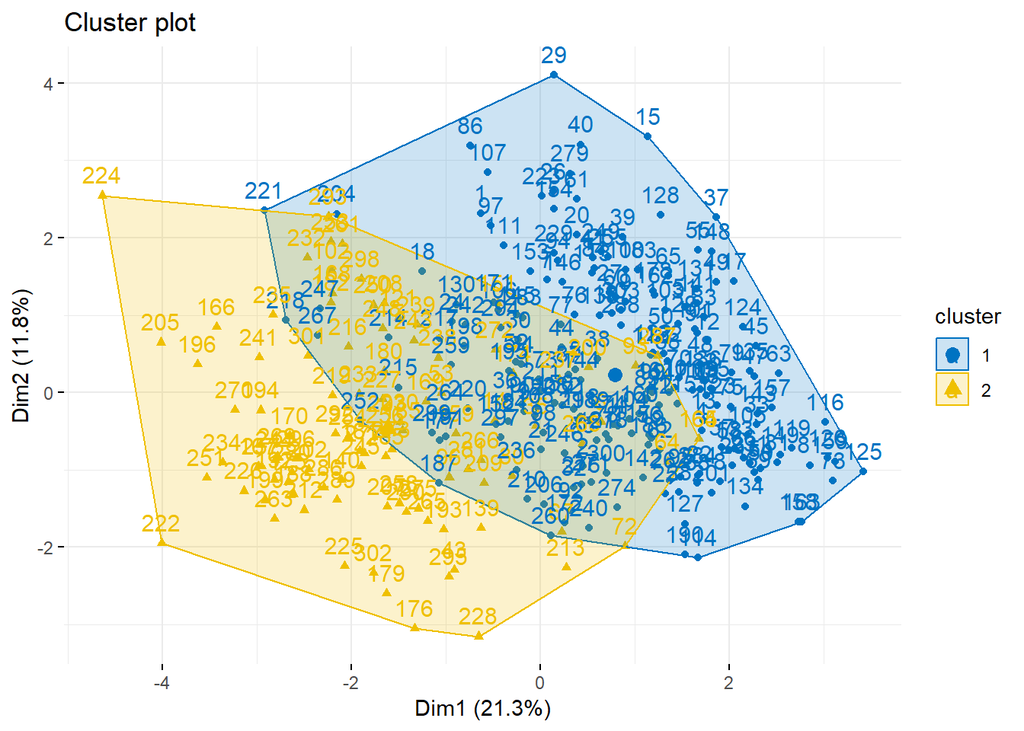

Na powyższym wykresie nie widać dobrze odzielonych klastrów.

## 6.2 Fuzzy clustering

```r
fuzzy <- fanny(Data, k=2)
```

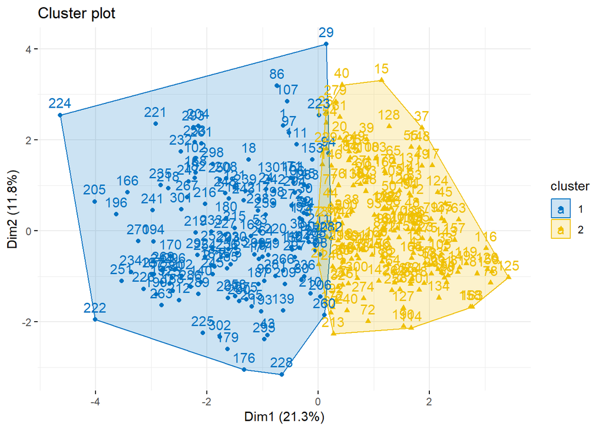

```r
fviz_cluster(fuzzy, data = Data,
             ellipse.type = "convex",
             palette = "jco",
             ggtheme = theme_minimal())
```

Na wykresie `Fuzzy Clustering` widzymy już całkiem dobry podział.

## 6.3 DBSCAN

Na początku wybierzemy optymalną wartość dla parametru `eps` powinna ona znajdować się na `kolanie` na poniższym wykresie.

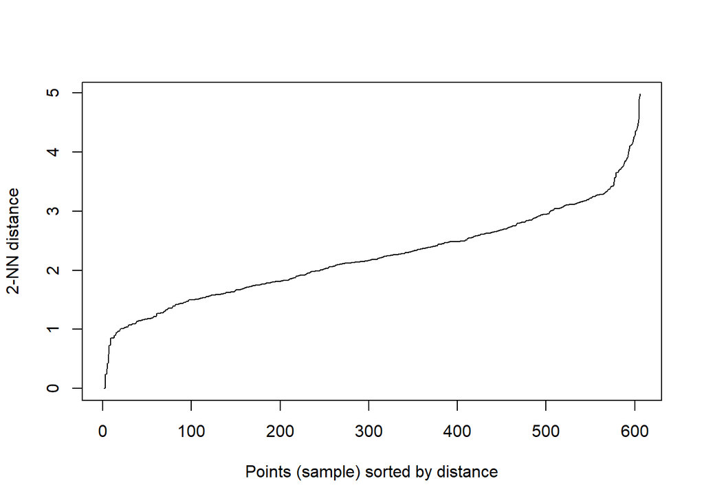

```r
dbscan::kNNdistplot(Data, k=2)
```

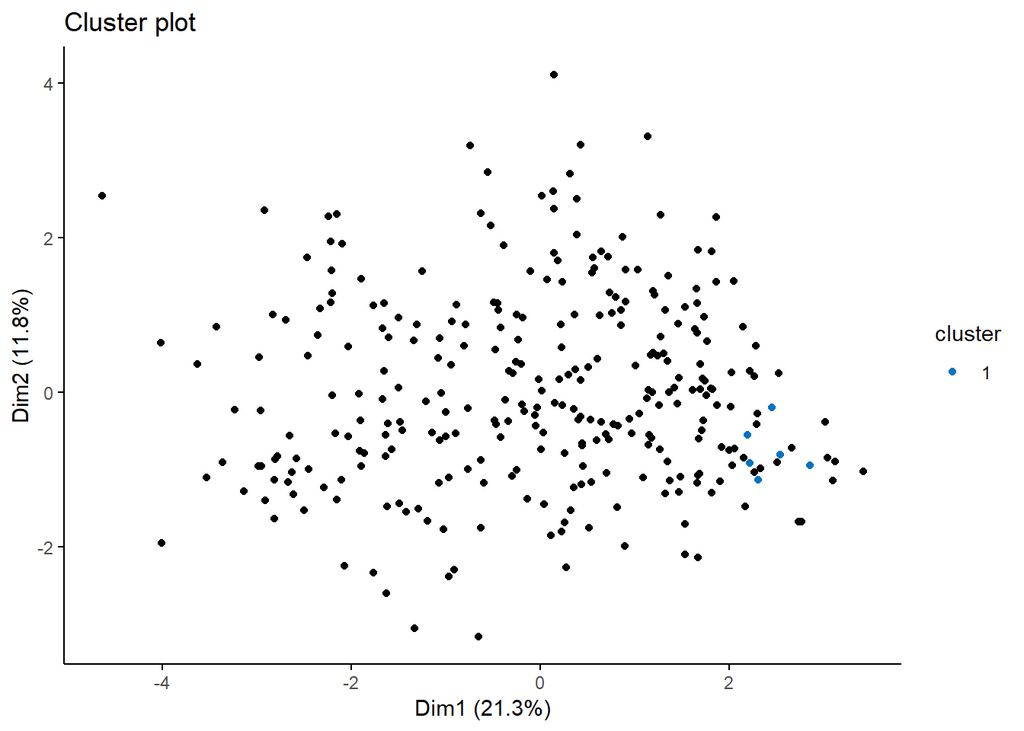

```r
library(fpc)

db <- fpc::dbscan(Data, eps = 1.2, MinPts = 5)

fviz_cluster(db, data = Data, stand = FALSE,
             ellipse = FALSE, show.clust.cent = FALSE,
             geom = "point",palette = "jco", ggtheme = theme_classic())
```

Tym razem algorytm podzielił zbiór na jeden klaster i wartości odstające, wskazuje to na inny sposób działania w porówaniu do pozostałych metod.